# oefeningen hoofdstuk 8 - tijdsreeksen

TijsMartens

12 april 2019

# voorbeelden van in de les.

```r
x <- round(rnorm(50, 50, 10))
x
```

```
##  [1] 54 52 57 49 32 59 55 49 46 44 42 56 30 59 50 56 56 41 55 69 26 44 60
## [24] 50 37 53 37 59 55 44 57 37 54 53 50 70 47 48 40 37 47 41 47 54 33 44
## [47] 31 59 59 51
```

```r
t <- ts(x, frequency = 5)
t
```

```
## Time Series:
## Start = c(1, 1)
## End = c(10, 5)
## Frequency = 5
##  [1] 54 52 57 49 32 59 55 49 46 44 42 56 30 59 50 56 56 41 55 69 26 44 60
## [24] 50 37 53 37 59 55 44 57 37 54 53 50 70 47 48 40 37 47 41 47 54 33 44
## [47] 31 59 59 51
```

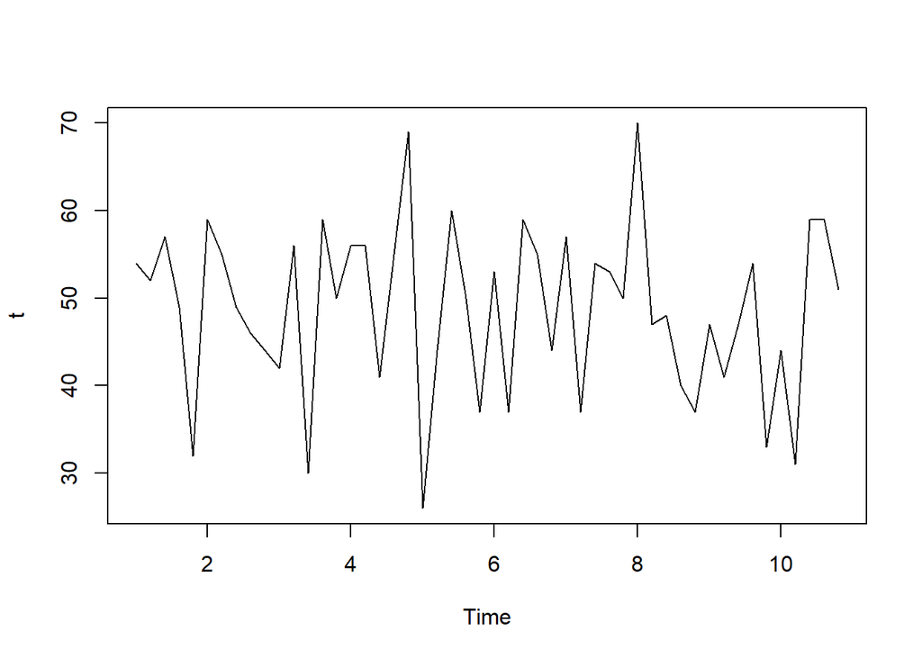

```r
plot(t)
```

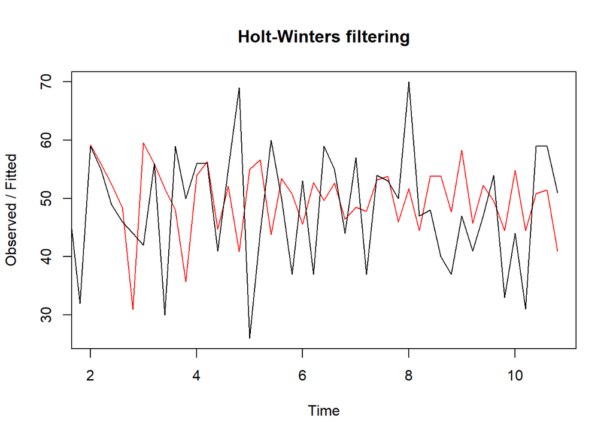

```r
fit <- HoltWinters(t)

plot(fit)
```

```r
fit
```

```
## Holt-Winters exponential smoothing with trend and additive seasonal component.
##
## Call:
## HoltWinters(x = t)
##
## Smoothing parameters:
##  alpha: 0
##  beta : 0
##  gamma: 0.3380351
##
## Coefficients:
##            [,1]
## a   52.51619048
## b    0.07428571
## s1  -1.04818078
## s2 -12.36007322
## s3   1.22917418
## s4   1.55745812
## s5  -8.15526300
```

merk op dat alpha heel klein is

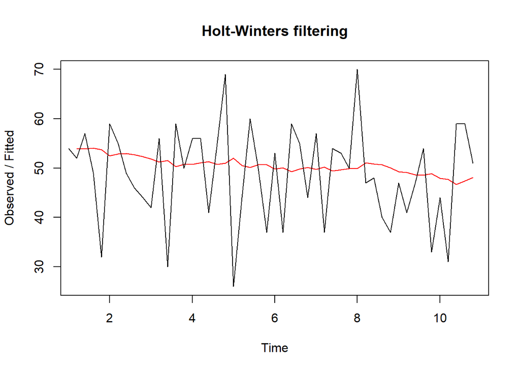

```r
fit <- HoltWinters(t,beta = FALSE, gamma =FALSE)

plot(fit)
```

```r
fit
```

```
## Holt-Winters exponential smoothing without trend and without seasonal component.
##
## Call:
## HoltWinters(x = t, beta = FALSE, gamma = FALSE)
##
## Smoothing parameters:
##  alpha: 0.05956138
##  beta : FALSE
##  gamma: FALSE
##
## Coefficients:
##      [,1]
## a 48.2948
```

merk op dat alpha groter is

# voorpselling maken

```r
library(forecast)
f <- forecast(fit, 5)
f
```

```
##       Point Forecast    Lo 80    Hi 80    Lo 95    Hi 95
## 11.00        48.2948 35.31064 61.27897 28.43724 68.15237
## 11.20        48.2948 35.28763 61.30198 28.40205 68.18756
## 11.40        48.2948 35.26466 61.32495 28.36692 68.22269
## 11.60        48.2948 35.24173 61.34788 28.33186 68.25775
## 11.80        48.2948 35.21884 61.37077 28.29685 68.29276
```

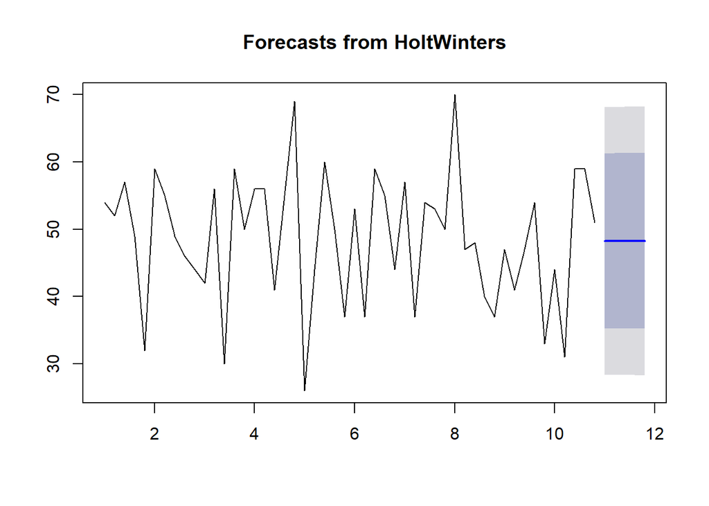

```r
plot(f)
```

## voorbeelde met stijgende data

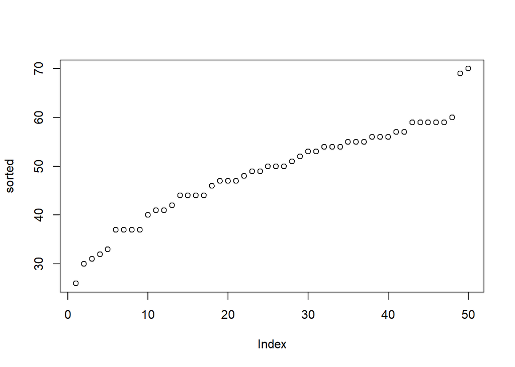

```r
sorted <- sort(x)
plot(sorted)
```

```r
# dataset laten veriëren
```

dataset laten veriëren:

```r
eta <- rnorm(50,0,2)
betaTS <- sorted + eta
```

tijdsreeks maken

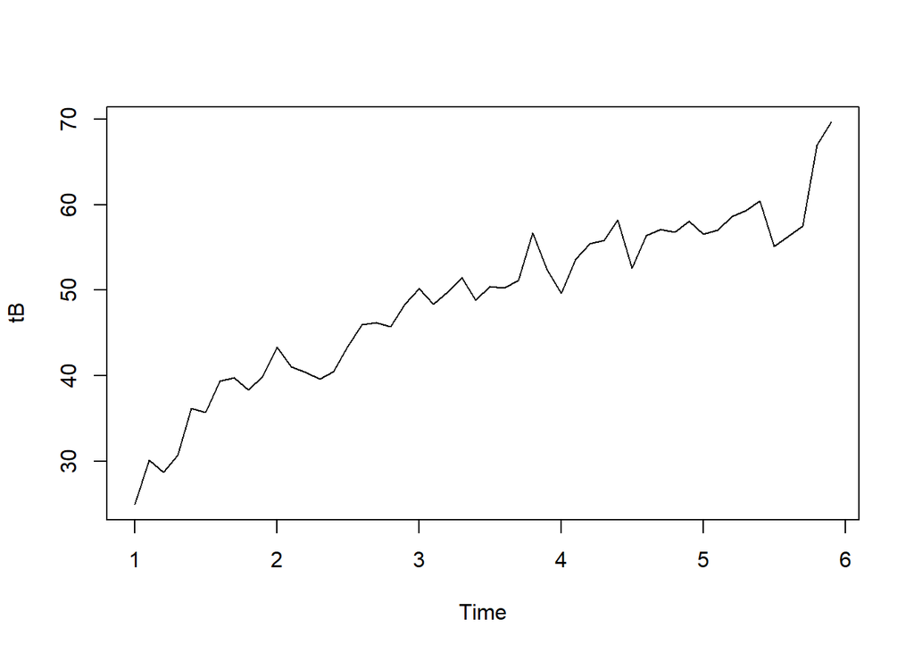

```r
tB <- ts(betaTS, frequency = 10)
plot(tB)
```

de grafiek stijgt, dus we moeten beta gerbuiken

```r
fitB <- HoltWinters(tB, alpha = TRUE, beta = TRUE, gamma=FALSE)
fitB
```

```
## Holt-Winters exponential smoothing with trend and without seasonal component.
##
## Call:
## HoltWinters(x = tB, alpha = TRUE, beta = TRUE, gamma = FALSE)
##
## Smoothing parameters:
##  alpha: TRUE
##  beta : TRUE
##  gamma: FALSE
##
## Coefficients:
##        [,1]
## a 69.657999
## b  2.635878
```

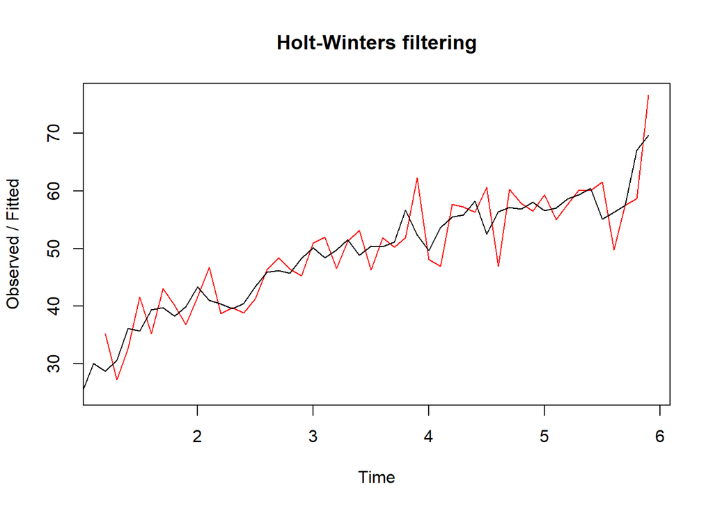

```r
plot(fitB)
```

## voorspelling maken

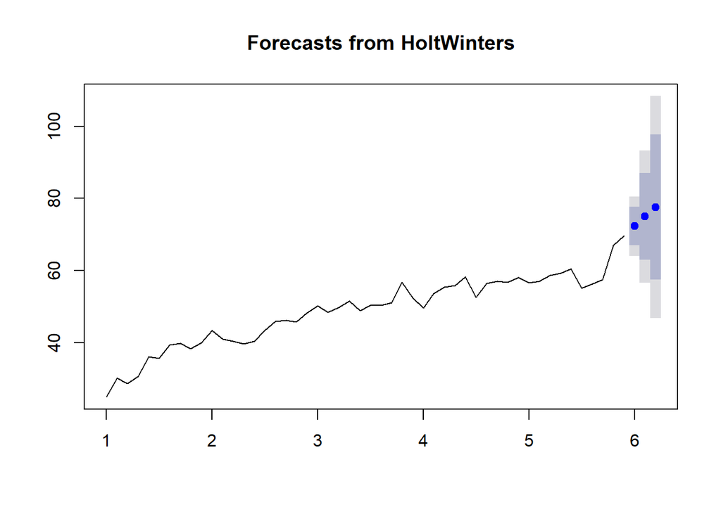

```r
fB <- forecast(fitB, 3)
plot(fB)
```

### werken met een seizoenscomponent

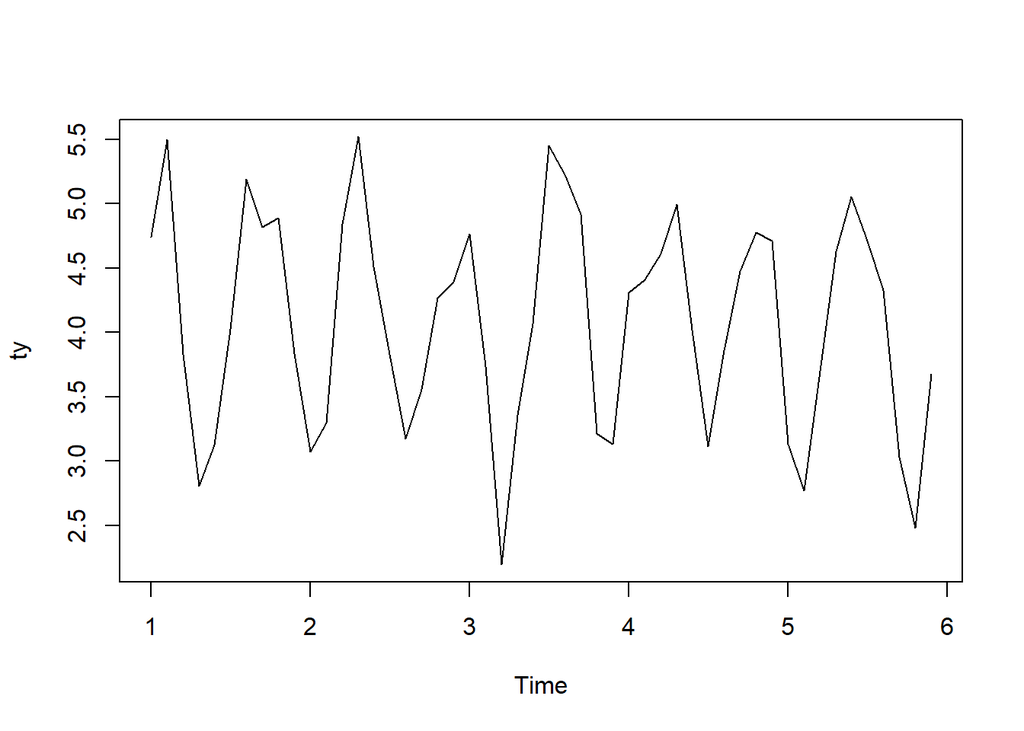

```r
x <- seq(1:50)
y <- sin(x)
eta <- rnorm(50,0, 0.5)
y <- y + 4 + eta
ty <- ts(y, frequency = 10)
plot(ty)
```

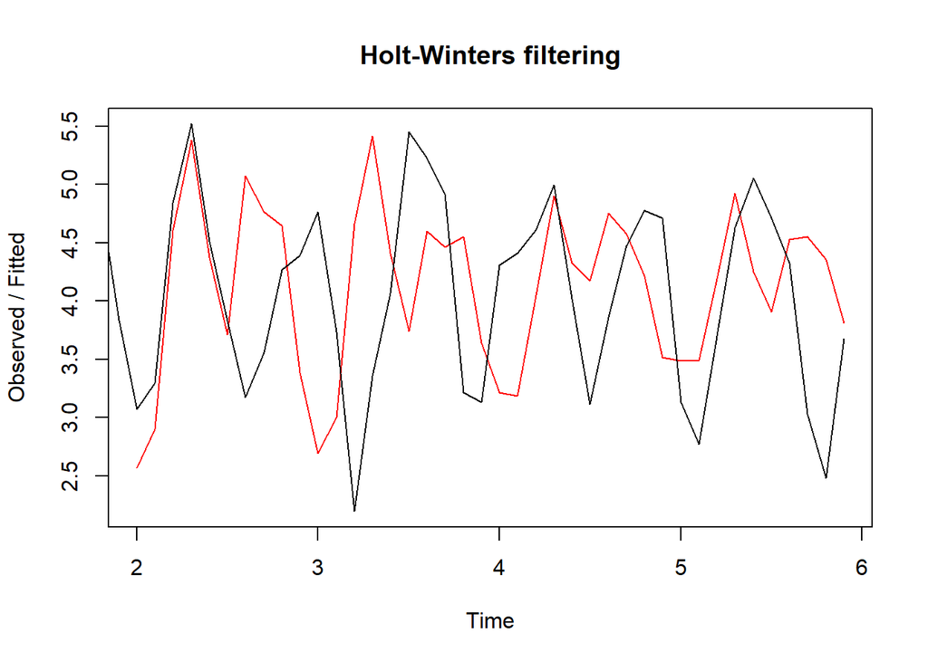

```r
my <- HoltWinters(ty)
plot(my)
```

```r
my
```

```
## Holt-Winters exponential smoothing with trend and additive seasonal component.
##
## Call:
## HoltWinters(x = ty)
##
## Smoothing parameters:
##  alpha: 0
##  beta : 0
##  gamma: 0.2502856
##
## Coefficients:
##              [,1]
## a    4.140364e+00
## b    3.264333e-06
## s1  -7.422423e-01
## s2  -8.318796e-01
## s3  -7.539979e-02
## s4   7.098440e-01
## s5   3.088919e-01
## s6  -3.408928e-02
## s7   3.382757e-01
## s8   2.726393e-02
## s9  -2.549453e-01
## s10 -3.627360e-01
```

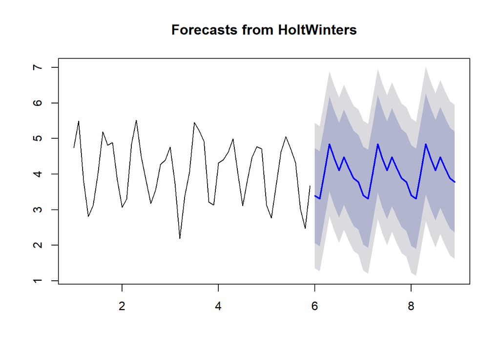

```r
##voorspelling
fy <- forecast(my, 30)
plot(fy)
```

merk op dat de periodes (de dalen en de pieken) worden meegenomen in de voorspelling

# voorbeeld blz 120: het voorstellen van een tijdsreeks

```r
kings <- scan(file = "C:\\Users\\tijsm\\Google Drive\\HoGent 2018-2019\\2e semester\\Onderzoekstechnieken\\files\\onderzoekstechnieken-cursus\\cursus\\data\\tijdreeksen\\kings.data", skip=3)

kings
```

```
##  [1] 60 43 67 50 56 42 50 65 68 43 65 34 47 34 49 41 13 35 53 56 16 43 69
## [24] 59 48 59 86 55 68 51 33 49 67 77 81 67 71 81 68 70 77 56
```

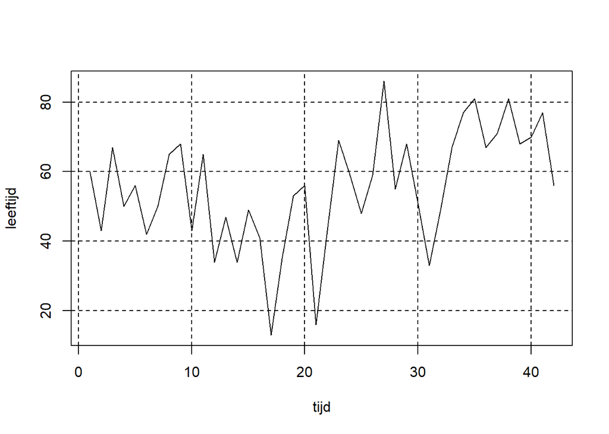

```r
kingstimeseries <- ts(kings)

plot.ts(kingstimeseries, ylab = "leeftijd", xlab="tijd")
grid(lty = 2, lwd = 1, col = "black")
```

# voorbeeld blz 123 ev. : voorschrijdend gemiddelde

```r
data <- c(4 , 16 , 12 , 25 , 13 , 12 , 4 , 8 , 9 , 14, 3 , 14 , 14 , 20 , 7 , 9 , 6 , 11 , 3 , 11, 8 , 7 , 2 , 8 , 8 , 10 , 7 , 16 , 9 , 4)

testData <- c(4 , 16 , 12 , 25 , 13 , 12 , 4 , 8 , 9 , 14, 3 , 14 , 14 , 20 , 7 , 9 , 6 , 11 , 3 , 11)

gem <- mean(data[1:20]) # het gemiddelde van de eerste 20 getallen
gem
```

```
## [1] 10.75
```

```r
mean(testData)
```

```
## [1] 10.75
```

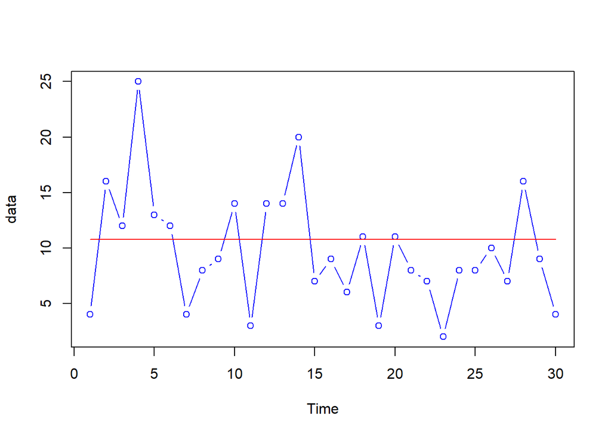

```r
gemy <- rnorm(n = length(data), mean = gem, sd = 0)

plot.ts(data, type = "b", col = "blue")
lines(gemy, type = "l", col = "red")
```

we merken dat x1 = 4 (de eerste waarde) evenveel invloed heeft op het gemiddelde als x20 = 11

het gemiddelde als schatter gebruiken is dus geen goed idee

```r
#library(smooth)
#library(Mcomp)


library('forecast')

#sma10 <- SMA(x =data,n=10)
#sma5 <- SMA(x=data,n=5)
#plot.ts(x = data, col = 'blue',type = 'l')
#lines(sma10, col='red', type = 'b')
#lines(sma5, col='purple', type = 'b')

# SMA function is niet gekend
```

# voorbeeld blz 126: enkelvoudige exponentiële afvakking

```r
rain <- kings <- scan(file = "C:\\Users\\tijsm\\Google Drive\\HoGent 2018-2019\\2e semester\\Onderzoekstechnieken\\files\\onderzoekstechnieken-cursus\\cursus\\data\\tijdreeksen\\precip.data", skip=1)

rain
```

```
##   [1] 23.56 26.07 21.86 31.24 23.65 23.88 26.41 22.67 31.69 23.86 24.11
##  [12] 32.43 23.26 22.57 23.00 27.88 25.32 25.08 27.76 19.82 24.78 20.12
##  [23] 24.34 27.42 19.44 21.63 27.49 19.43 31.13 23.09 25.85 22.65 22.75
##  [34] 26.36 17.70 29.81 22.93 19.22 20.63 35.34 25.89 18.65 23.06 22.21
##  [45] 22.18 18.77 28.21 32.24 22.27 27.57 21.59 16.93 29.48 31.60 26.25
##  [56] 23.40 25.42 21.32 25.02 33.86 22.67 18.82 28.44 26.16 28.17 34.08
##  [67] 33.82 30.28 27.92 27.14 24.40 20.35 26.64 27.01 19.21 27.74 23.85
##  [78] 21.23 28.15 22.61 19.80 27.94 21.47 23.52 22.86 17.69 22.54 23.28
##  [89] 22.17 20.84 38.10 20.65 22.97 24.26 23.01 23.67 26.75 25.36 24.79
## [100] 27.88
```

```r
rainseries <- ts(rain, start = c(1813))
rainseries
```

```
## Time Series:
## Start = 1813
## End = 1912
## Frequency = 1
##   [1] 23.56 26.07 21.86 31.24 23.65 23.88 26.41 22.67 31.69 23.86 24.11
##  [12] 32.43 23.26 22.57 23.00 27.88 25.32 25.08 27.76 19.82 24.78 20.12
##  [23] 24.34 27.42 19.44 21.63 27.49 19.43 31.13 23.09 25.85 22.65 22.75
##  [34] 26.36 17.70 29.81 22.93 19.22 20.63 35.34 25.89 18.65 23.06 22.21
##  [45] 22.18 18.77 28.21 32.24 22.27 27.57 21.59 16.93 29.48 31.60 26.25
##  [56] 23.40 25.42 21.32 25.02 33.86 22.67 18.82 28.44 26.16 28.17 34.08
##  [67] 33.82 30.28 27.92 27.14 24.40 20.35 26.64 27.01 19.21 27.74 23.85
##  [78] 21.23 28.15 22.61 19.80 27.94 21.47 23.52 22.86 17.69 22.54 23.28
##  [89] 22.17 20.84 38.10 20.65 22.97 24.26 23.01 23.67 26.75 25.36 24.79
## [100] 27.88
```

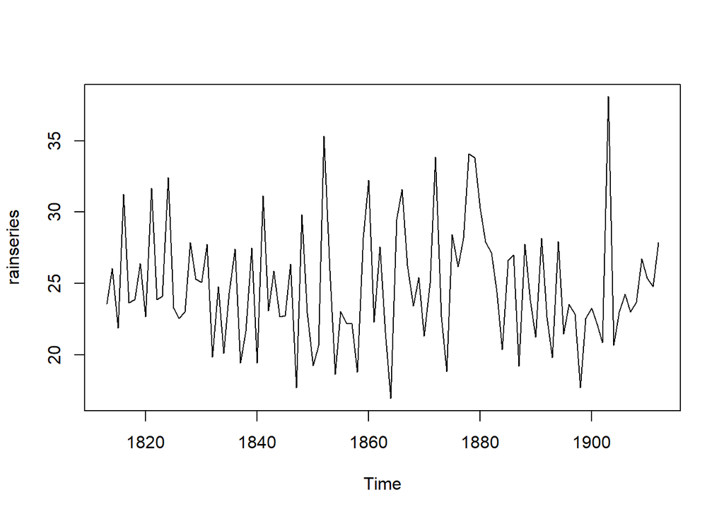

```r
plot.ts(rainseries)
```

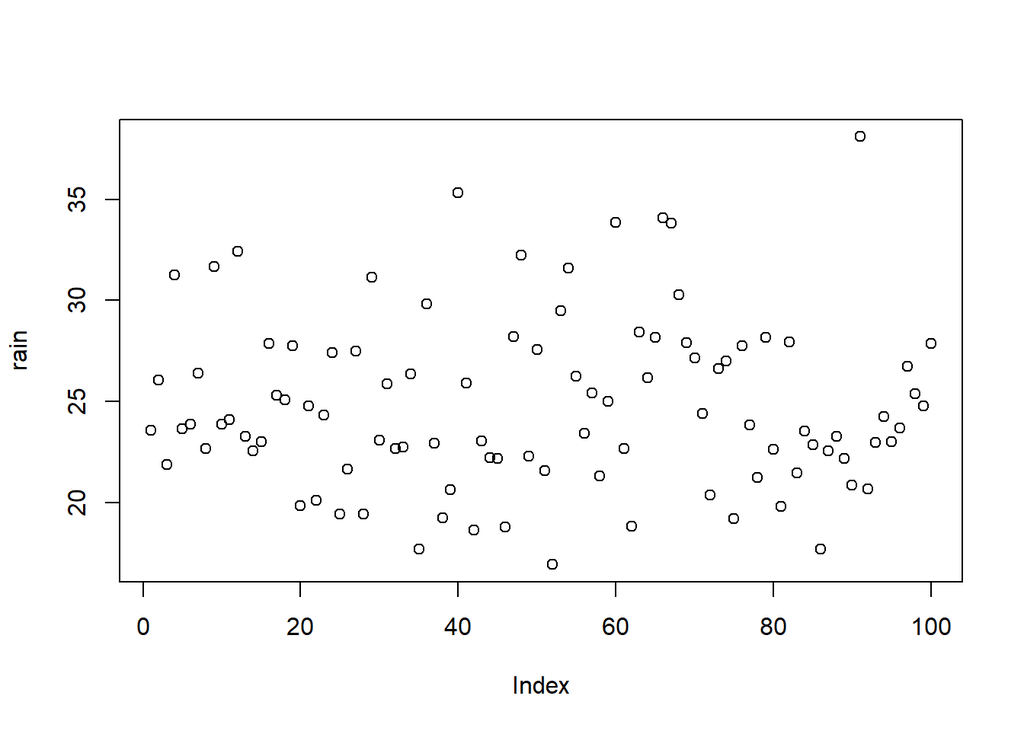

```r
plot(rain) # van waar komt dit forecast??????
```

# oefening 8.1.

## opgave

wat zou volgende tijdsreeks kunnen voorstellen

## oplossing

tijdsreeks grafisch voorstellen

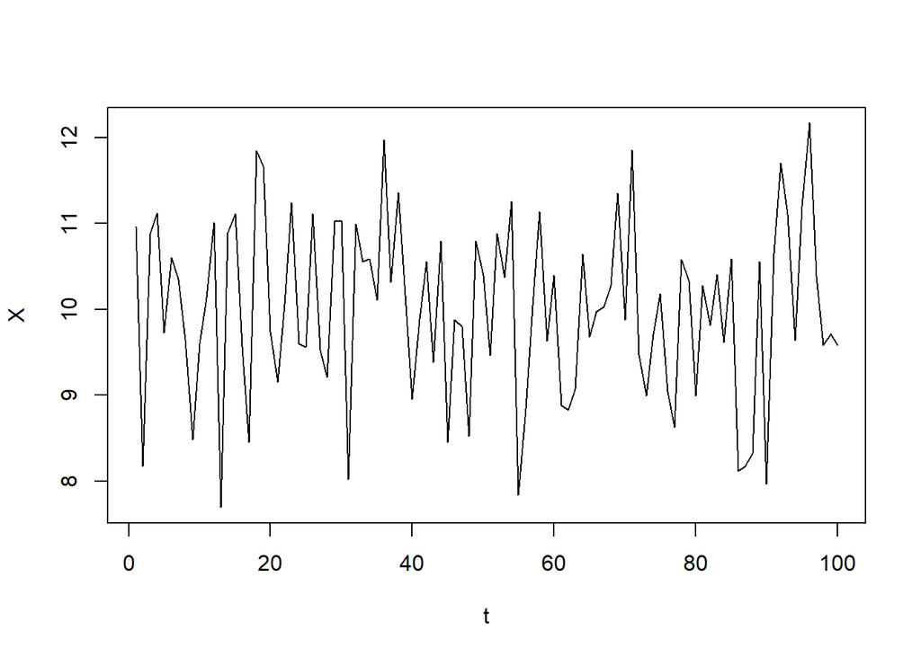

```r
f <- function (a , b , t ){
    return (a + b * sin ((2 * pi*4) / 4) + b * cos ((2 * pi*4) / 4) + rnorm (1) )
}


t <- seq(from = 1, to = 100, by = 1)


X <- lapply (t , f , a=5,b=5)

plot (x = t , y = X, type = 'l')
```

# oefening 8.2.

```r
budgets <- read.csv("C:\\Users\\tijsm\\Google Drive\\HoGent 2018-2019\\2e semester\\Onderzoekstechnieken\\files\\onderzoekstechnieken-cursus\\oefeningen\\data\\hfst8_tijdsreeksen\\budget.csv")

budgets
```

| Kwartaal | Omzet | AdBudget | BNP | Kwartaalnummer |
| --- | --- | --- | --- | --- |
| Mar-81 | 1020.2 | 659.2 | 251.8 | 1 |
| Jun-81 | 889.2 | 589.0 | 290.9 | 2 |
| Sep-81 | 795.0 | 512.5 | 290.8 | 3 |
| Dec-81 | 1003.9 | 614.1 | 292.4 | 4 |
| Mar-82 | 1057.7 | 647.2 | 279.1 | 5 |
| Jun-82 | 944.4 | 602.0 | 254.0 | 6 |
| Sep-82 | 778.5 | 530.7 | 295.6 | 7 |
| Dec-82 | 932.5 | 608.4 | 271.7 | 8 |
| Mar-83 | 996.5 | 637.9 | 259.6 | 9 |
| Jun-83 | 907.7 | 582.4 | 280.5 | 10 |

[output cut: 90 more lines]

```r
library(TTR)
```

```r
library(forecast)
library(ggplot2)
```

## 1.

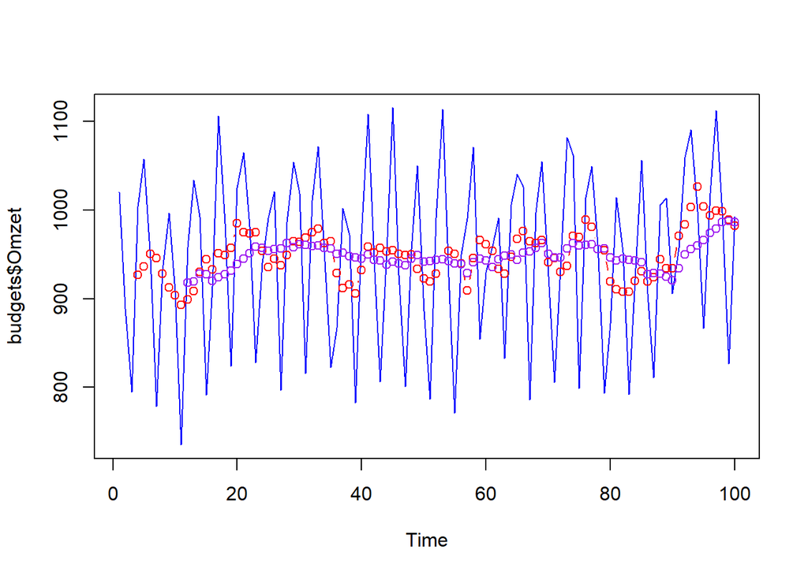

```r
omzetsma4 <- SMA(x = budgets$Omzet, n=4)
omzetsma12 <- SMA(x = budgets$Omzet, n=12)
plot.ts(x=budgets$Omzet, col="blue", type = 'l')


lines(omzetsma4, col = "red", type = 'b')
lines(omzetsma12, col = "purple", type = 'b')
```

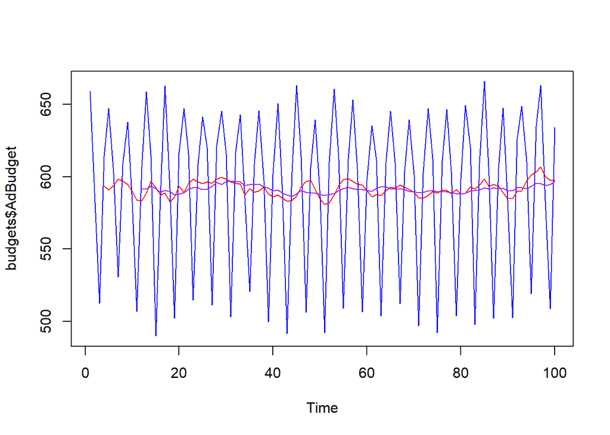

```r
addsBudgetsma4 <- SMA(budgets$AdBudget, n = 4)
addsBudgetsma12 <- SMA(budgets$AdBudget, n = 12)

plot.ts(x = budgets$AdBudget, col='blue', type = 'l')

lines(addsBudgetsma4, col = 'red', type = 'l')
lines(addsBudgetsma12, col = 'purple', type = 'l')
```

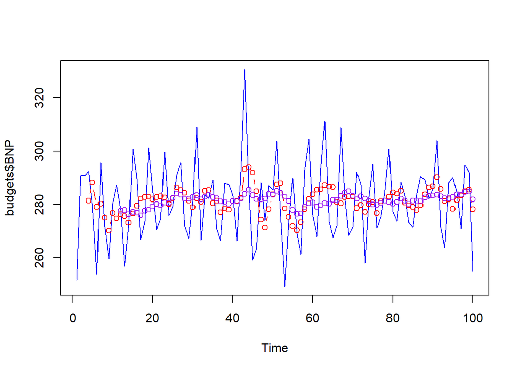

```r
bnpsma4 <- SMA(budgets$BNP, n = 4)
bnpsma12 <- SMA(budgets$BNP, n = 12)

plot.ts(budgets$BNP, col = 'blue', type = 'l')

lines(bnpsma4, col = "red", type = 'b')
lines(bnpsma12, col = "purple", type = "b")
```

## 2.

adhv lineaire regressie

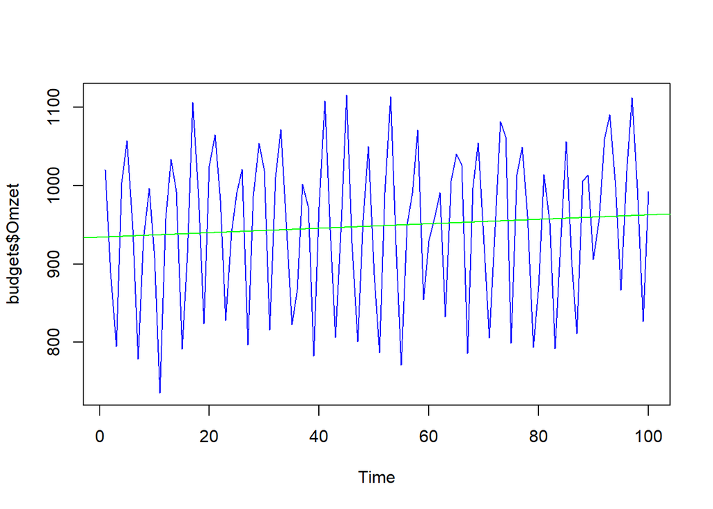

```r
linregOmzet <- lm(budgets$Omzet ~ budgets$Kwartaalnummer)
plot.ts(x = budgets$Omzet, col='blue', type = 'l')

abline(linregOmzet, col = 'green')
```

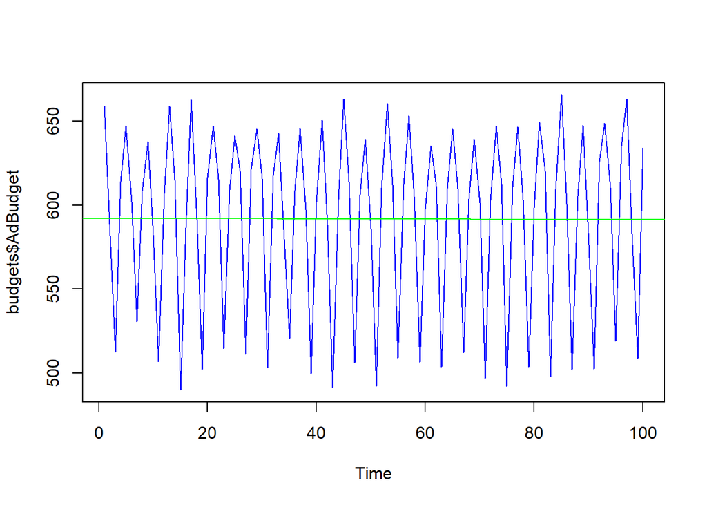

```r
linregAddsBudget <- lm(budgets$AdBudget ~ budgets$Kwartaalnummer)
plot.ts(x = budgets$AdBudget, col='blue', type = 'l')

abline(linregAddsBudget, col = 'green')
```

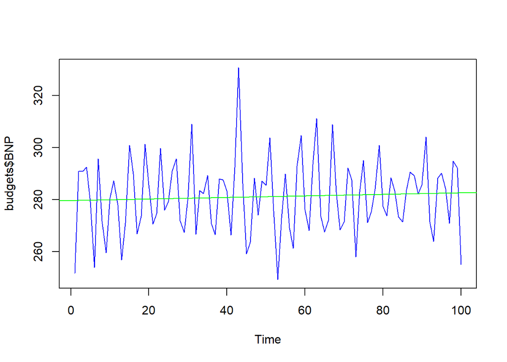

```r
linregbnp <- lm(budgets$BNP ~ budgets$Kwartaalnummer)
plot.ts(x = budgets$BNP, col='blue', type = 'l')

abline(linregbnp, col = 'green')
```

## 3.

```r
voorspellingOmzet4 <- forecast(omzetsma4, h=10)
```

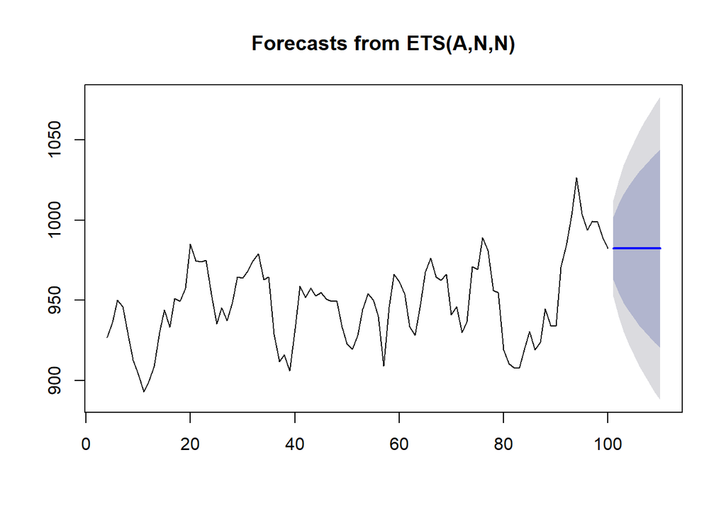

```r
plot(voorspellingOmzet4)
```

```r
voorspellingOmzet12 <- forecast(omzetsma12, h=10)
```

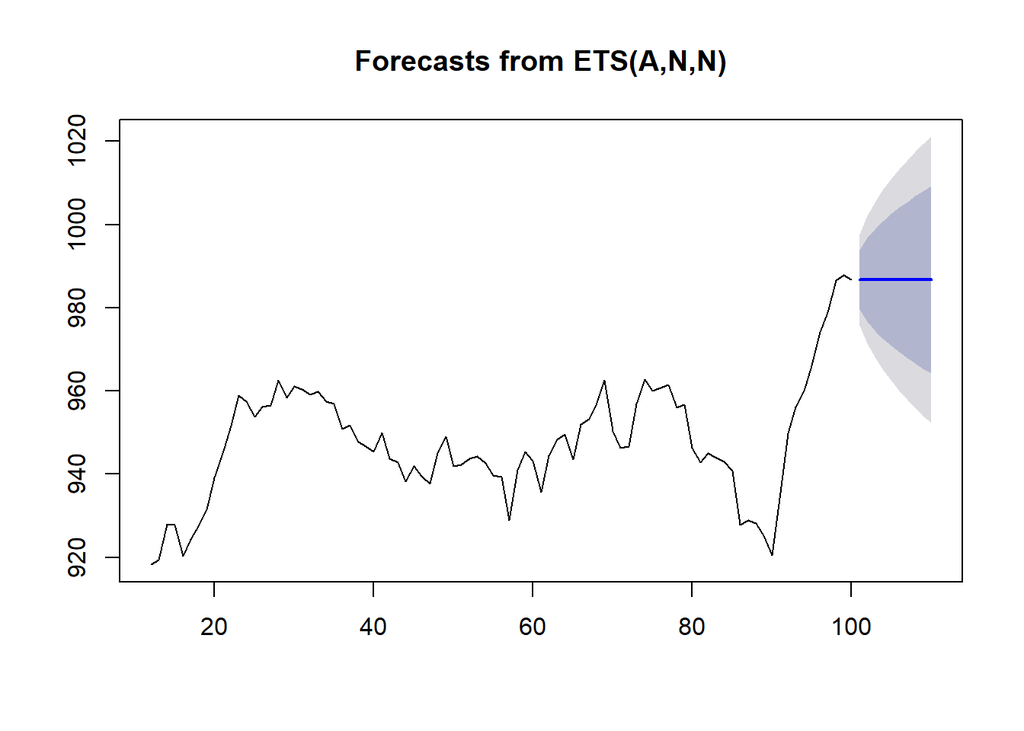

```r
plot(voorspellingOmzet12)
```

```r
voorspellingAdBudget4 <- forecast(addsBudgetsma4, h=10)
```

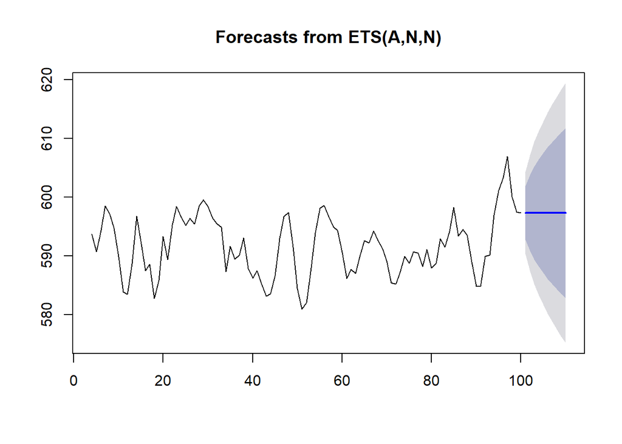

```r
plot(voorspellingAdBudget4)
```

```r
voorspellingAdBudget12 <- forecast(addsBudgetsma12, h=10)
```

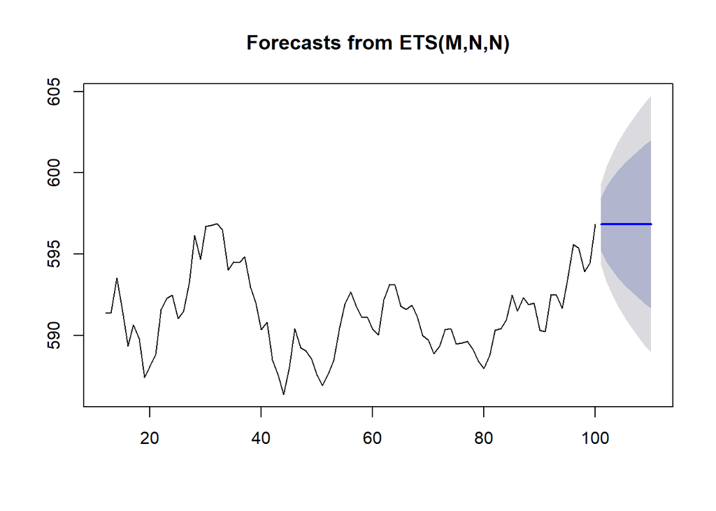

```r
plot(voorspellingAdBudget12)
```

```r
voorspellingBNP4 <- forecast(bnpsma4, h=10)
```

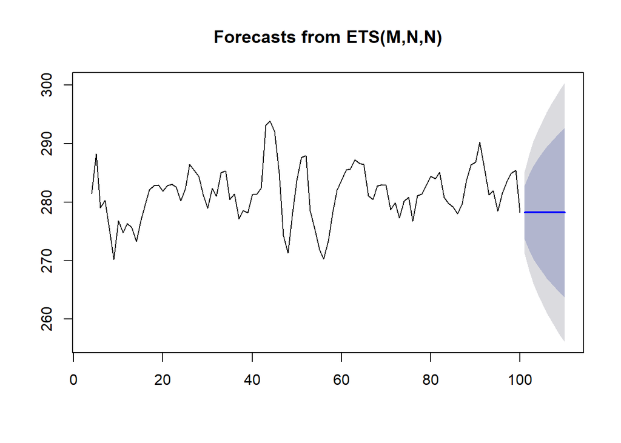

```r
plot(voorspellingBNP4)
```

```r
voorspellingBNP12 <- forecast(bnpsma12, h=10)
```

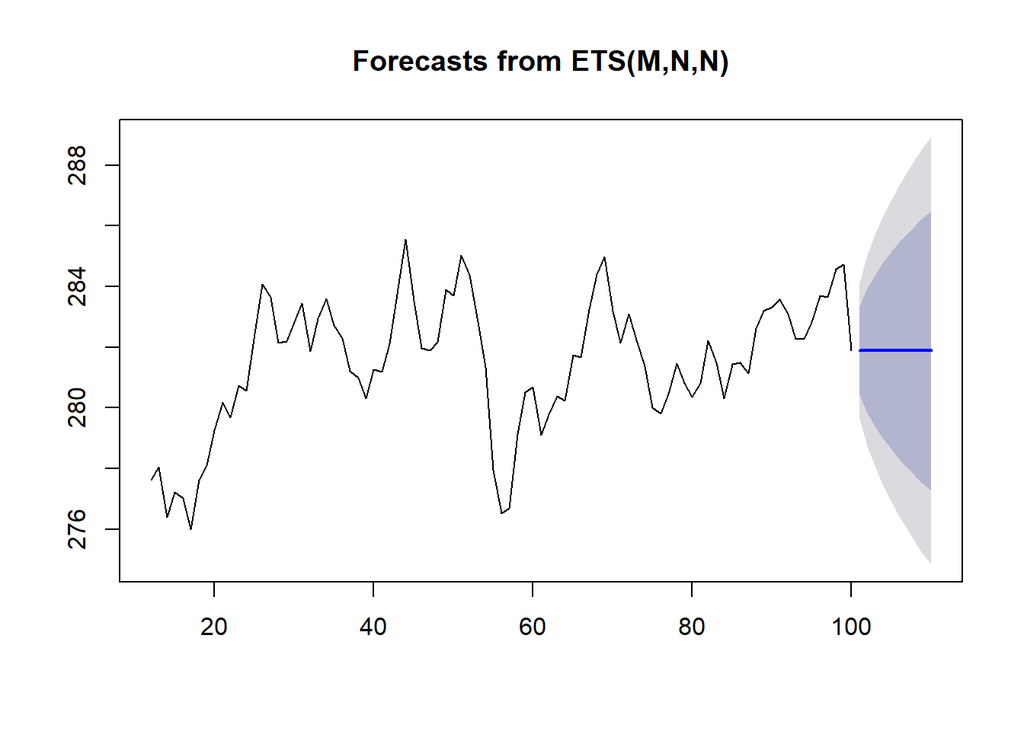

```r
plot(voorspellingBNP12)
```

## 4.

aangezien er 4 kwartalen zijn in een jaar is deze dataset “seasonal”. Voor dit soort data set is driedubbele exponentiële smoothing voorzien.

Als er enkel een trend was, zou dubbele exponentiele smoothing volstaan.

## 5.

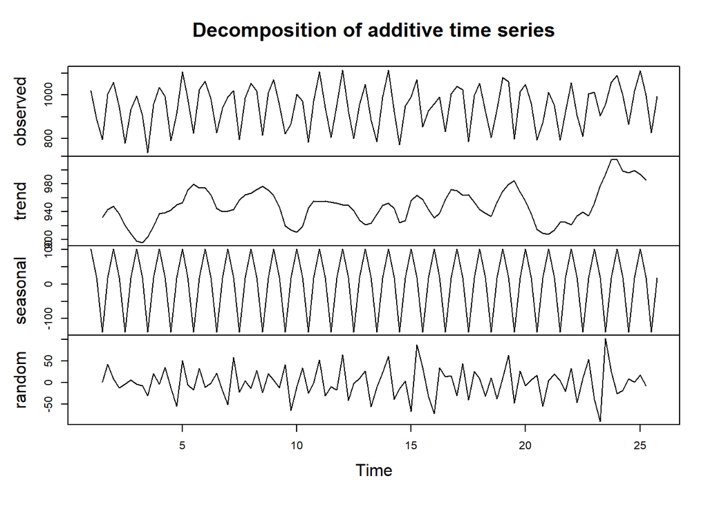

```r
omzetTs <- ts(budgets$Omzet, frequency = 4)
decomposedOmzet <- decompose(omzetTs)
plot(decomposedOmzet)
```

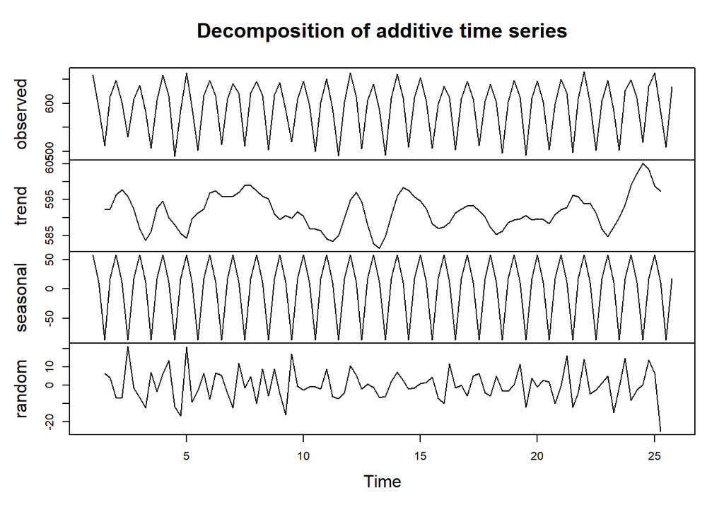

```r
addsBudgetTs <- ts(budgets$AdBudget, frequency = 4)
decomposedAddsTs <- decompose(addsBudgetTs)
plot(decomposedAddsTs)
```

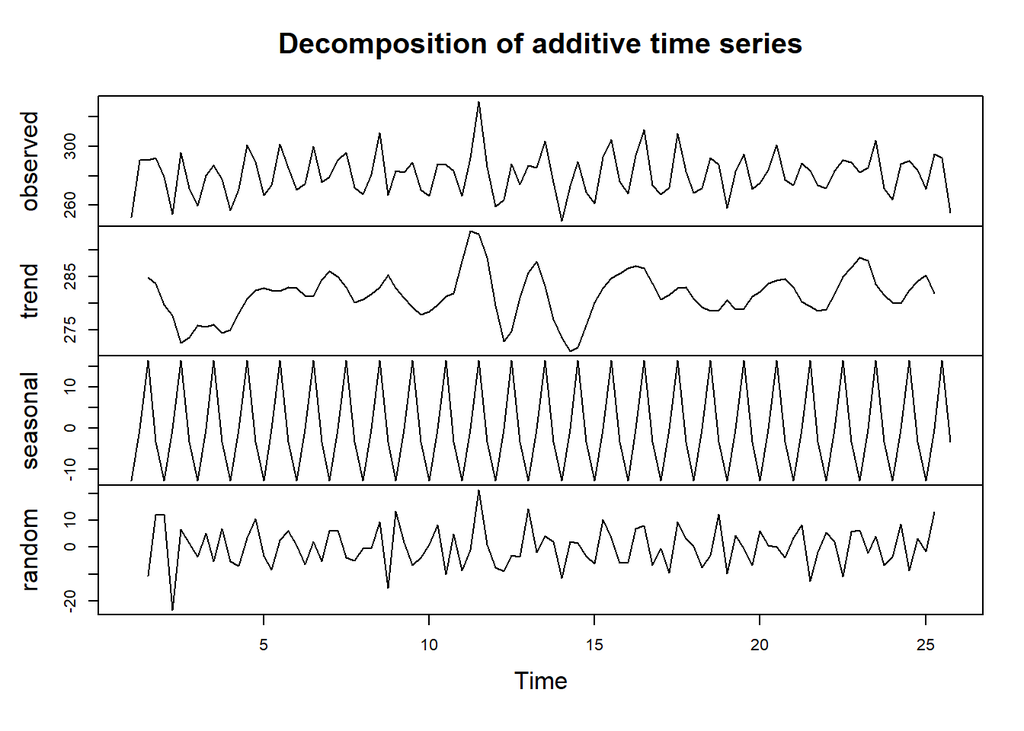

```r
bnpTs <- ts(budgets$BNP, frequency = 4)
decomposedBnpTs <- decompose(bnpTs)
plot(decomposedBnpTs)
```